# Life Expectancy Predictor

Riya Kalra

2024-12-15

$$\text{Life.Exp} = \beta_0 + \beta_1 \cdot \text{Murder} + \beta_2 \cdot
\text{HS.Grad} + \beta_3 \cdot \text{Frost} + \beta_4 \cdot
\text{Population}$$

R dataset state.x77 from library(faraway) contains information on 50 states from 1970s collected by US Census Bureau. The goal is to predict ‘life expectancy’ using a combination of remaining variables.

### a) First we load the dataset and provide descriptive statistics for all variables of interest.

```r
data(state)
state_data <- as.data.frame(state.x77)

# Descriptive statistics
summary(state_data)
```

```
##    Population        Income       Illiteracy       Life Exp
##  Min.   :  365   Min.   :3098   Min.   :0.500   Min.   :67.96
##  1st Qu.: 1080   1st Qu.:3993   1st Qu.:0.625   1st Qu.:70.12
##  Median : 2838   Median :4519   Median :0.950   Median :70.67
##  Mean   : 4246   Mean   :4436   Mean   :1.170   Mean   :70.88
##  3rd Qu.: 4968   3rd Qu.:4814   3rd Qu.:1.575   3rd Qu.:71.89
##  Max.   :21198   Max.   :6315   Max.   :2.800   Max.   :73.60
##      Murder          HS Grad          Frost             Area
##  Min.   : 1.400   Min.   :37.80   Min.   :  0.00   Min.   :  1049
##  1st Qu.: 4.350   1st Qu.:48.05   1st Qu.: 66.25   1st Qu.: 36985
##  Median : 6.850   Median :53.25   Median :114.50   Median : 54277
##  Mean   : 7.378   Mean   :53.11   Mean   :104.46   Mean   : 70736
##  3rd Qu.:10.675   3rd Qu.:59.15   3rd Qu.:139.75   3rd Qu.: 81162
##  Max.   :15.100   Max.   :67.30   Max.   :188.00   Max.   :566432
```

```r
sapply(state_data, sd)  # Standard deviations
```

```
##   Population       Income   Illiteracy     Life Exp       Murder      HS Grad
## 4.464491e+03 6.144699e+02 6.095331e-01 1.342394e+00 3.691540e+00 8.076998e+00
##        Frost         Area
## 5.198085e+01 8.532730e+04
```

```r
# Convert all variables to numeric using lapply
state_data <- as.data.frame(lapply(state_data, as.numeric))

# Confirm all variables are numeric
str(state_data)
```

```
## 'data.frame':    50 obs. of  8 variables:
##  $ Population: num  3615 365 2212 2110 21198 ...
##  $ Income    : num  3624 6315 4530 3378 5114 ...
##  $ Illiteracy: num  2.1 1.5 1.8 1.9 1.1 0.7 1.1 0.9 1.3 2 ...
##  $ Life.Exp  : num  69 69.3 70.5 70.7 71.7 ...
##  $ Murder    : num  15.1 11.3 7.8 10.1 10.3 6.8 3.1 6.2 10.7 13.9 ...
##  $ HS.Grad   : num  41.3 66.7 58.1 39.9 62.6 63.9 56 54.6 52.6 40.6 ...
##  $ Frost     : num  20 152 15 65 20 166 139 103 11 60 ...
##  $ Area      : num  50708 566432 113417 51945 156361 ...
```

Now we can create some plots. We can start with a scatterplot matrix of multiple variables to get a better idea of correlations between them.

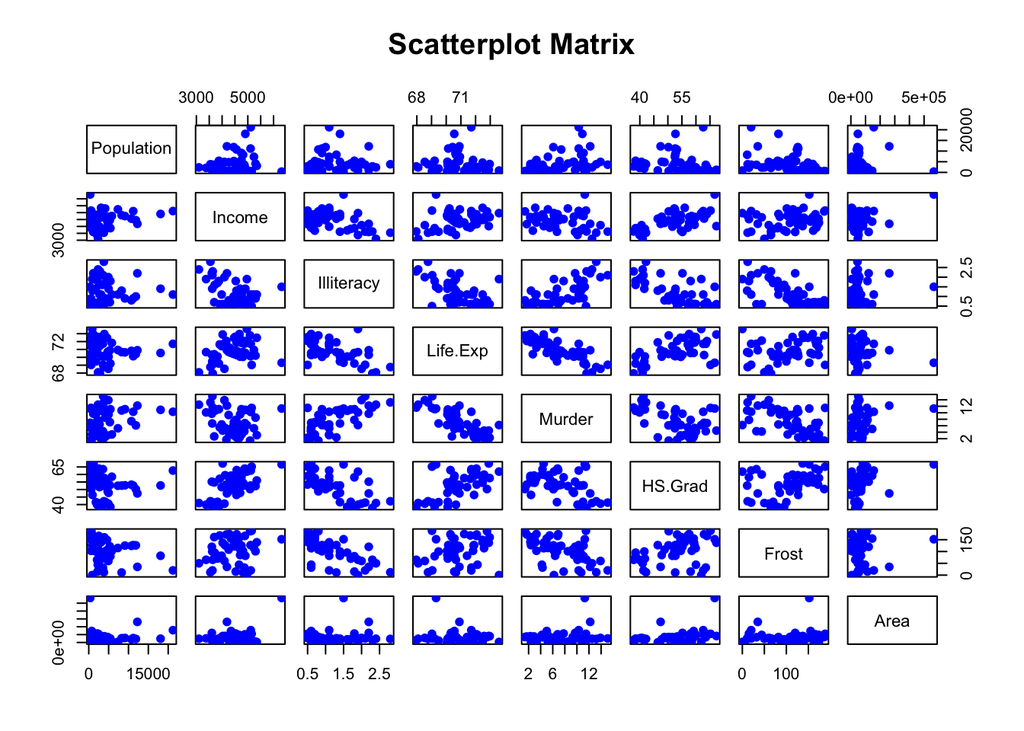

```r
pairs(state_data,
      main = "Scatterplot Matrix",
      col = "blue",
      pch = 19)
```

We can now make a heatmap that gives us more specific data. From this, we can see that life expectancy may be correlated with the murder, high school graduation, and illiteracy variables. We may also want to consider income or frost.

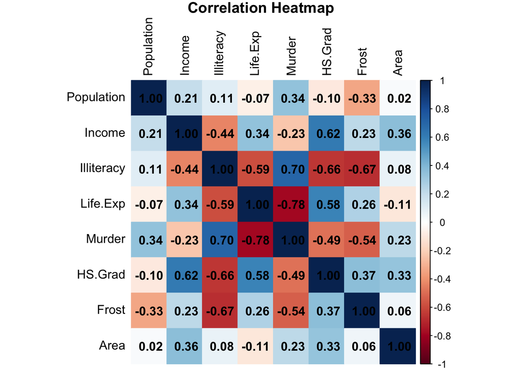

```r
# Compute correlation matrix
cor_matrix <- cor(state_data)

# Visualize correlations
corrplot(cor_matrix, method = "color", addCoef.col = "black", tl.col = "black",
         title = "Correlation Heatmap", mar = c(0, 0, 1, 0))
```

Next we pair some of the more correlated variables to get a better look.

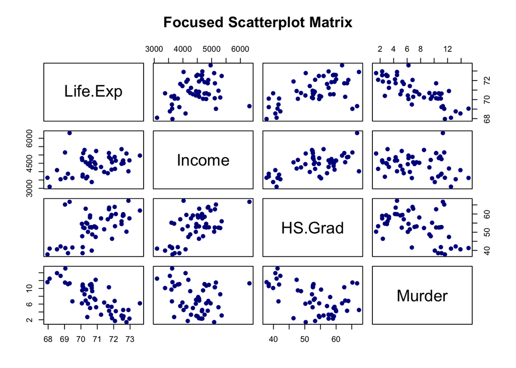

```r
pairs(state_data[, c("Life.Exp", "Income", "HS.Grad", "Murder")],
      main = "Focused Scatterplot Matrix",
      col = "darkblue", pch = 19)
```

### b) Examine the plots and decide transformations

The **scatterplot matrix** and **correlation heatmap** reveal key relationships among `Life.Exp`, `Income`, `HS.Grad`, and `Murder`. The scatterplots show that **life expectancy** has a positive relationship with both **income** and **high school graduation rates**, indicating that states with higher income and education levels tend to have longer life expectancy. Conversely, life expectancy exhibits a strong **negative relationship** with **murder rates**, suggesting that higher crime rates are associated with lower life expectancy. The positive relationship between **income** and **HS graduation rates** highlights that states with higher incomes tend to have better education outcomes. Additionally, a negative relationship is observed between **murder rates** and both **income** and **HS graduation rates**, indicating that higher education and income levels may contribute to lower crime rates.

The **correlation heatmap** quantifies these relationships. `Life.Exp` is strongly negatively correlated with `Murder` (-0.78) and positively correlated with `HS.Grad` (0.58) and `Income` (0.34). `HS.Grad` and `Illiteracy` have a strong negative correlation (-0.66), reflecting the inverse relationship between education and illiteracy. Similarly, **murder rates** are positively correlated with `Illiteracy` (0.70) and negatively correlated with `HS.Grad` (-0.49), further underscoring the importance of education in reducing crime. Weak correlations between variables like `Area` and `Population` suggest limited influence on life expectancy or education outcomes. Together, these plots highlight the interconnected roles of income, education, and crime in influencing life expectancy across states.

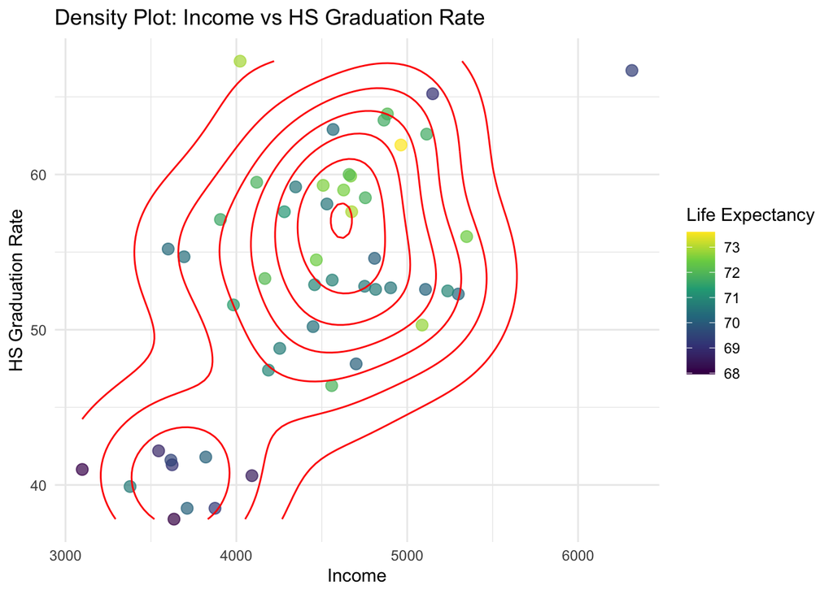

```r
ggplot(state_data, aes(x = Income, y = HS.Grad)) +
  geom_point(aes(color = Life.Exp), size = 3, alpha = 0.7) +
  geom_density_2d(color = "red") +
  scale_color_viridis_c() +
  labs(title = "Density Plot: Income vs HS Graduation Rate",
       x = "Income", y = "HS Graduation Rate", color = "Life Expectancy") +
  theme_minimal()
```

### Transformations

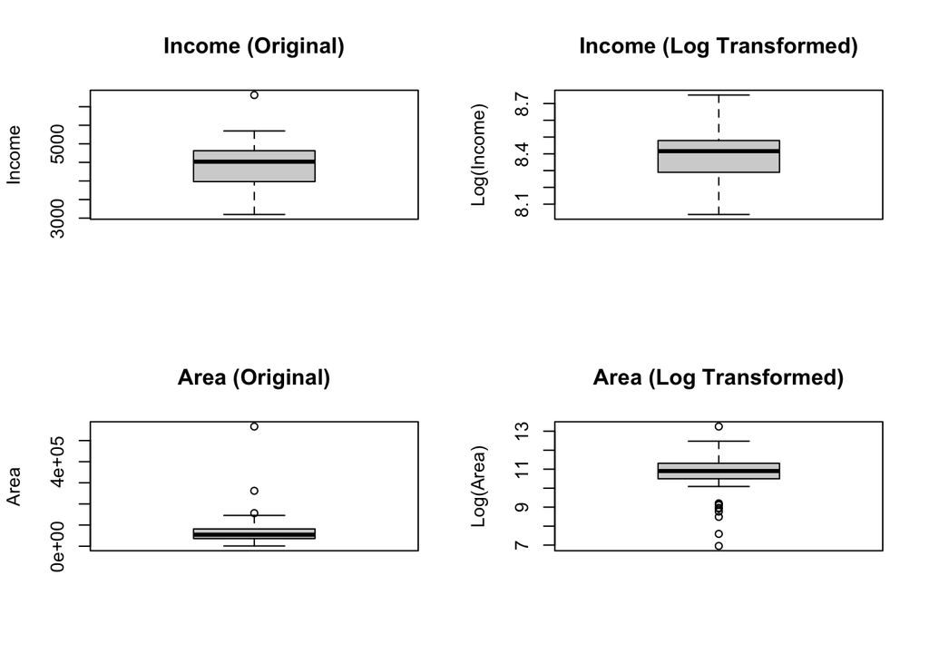

```r
par(mfrow = c(2, 2))
boxplot(state_data$Income, main = "Income (Original)", ylab = "Income")
boxplot(log(state_data$Income), main = "Income (Log Transformed)", ylab = "Log(Income)")

boxplot(state_data$Area, main = "Area (Original)", ylab = "Area")
boxplot(log(state_data$Area), main = "Area (Log Transformed)", ylab = "Log(Area)")
```

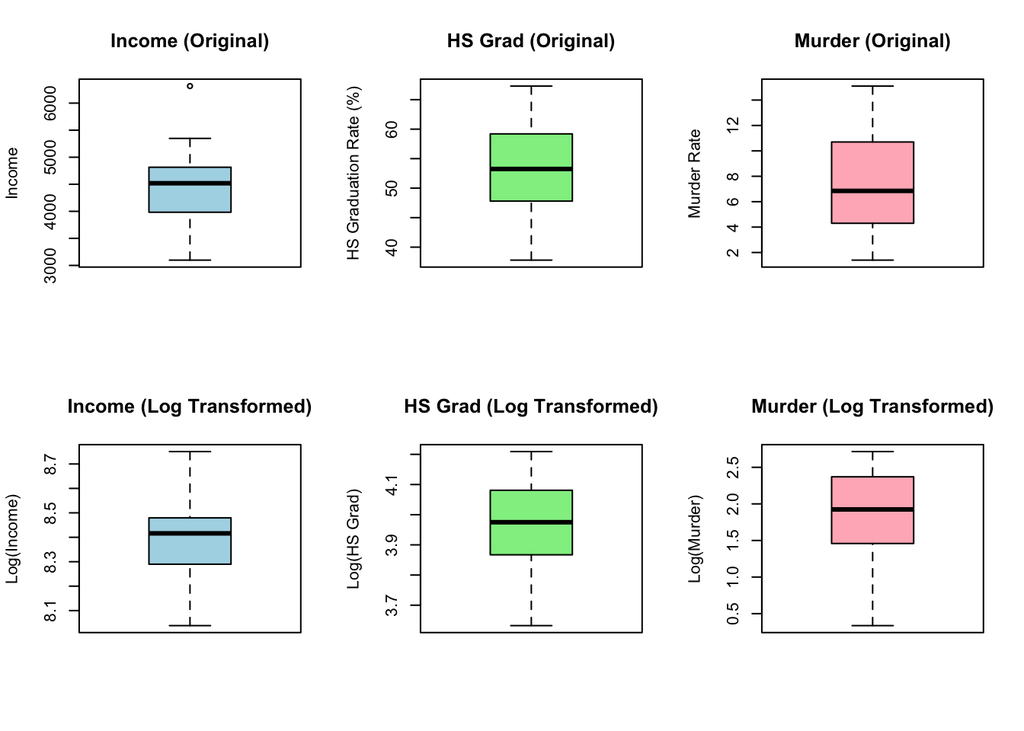

```r
par(mfrow = c(1, 1))

# Boxplots for Income, HS.Grad, and Murder (before and after log transformation)

# Set up a 2x3 plotting layout
par(mfrow = c(2, 3))  # 2 rows, 3 columns

# Original Boxplots
boxplot(state_data$Income, main = "Income (Original)", ylab = "Income", col = "lightblue")
boxplot(state_data$HS.Grad, main = "HS Grad (Original)", ylab = "HS Graduation Rate (%)", col = "lightgreen")
boxplot(state_data$Murder, main = "Murder (Original)", ylab = "Murder Rate", col = "lightpink")

# Log-Transformed Boxplots
boxplot(log(state_data$Income), main = "Income (Log Transformed)", ylab = "Log(Income)", col = "lightblue")
boxplot(log(state_data$HS.Grad), main = "HS Grad (Log Transformed)", ylab = "Log(HS Grad)", col = "lightgreen")
boxplot(log(state_data$Murder), main = "Murder (Log Transformed)", ylab = "Log(Murder)", col = "lightpink")
```

```r
# Reset layout
par(mfrow = c(1, 1))
```

#### P-values for predictors

P-Values for Individual Predictors

| Variable | P-Value |
| --- | --- |
| Murder | 2.260070e-11 |
| Illiteracy | 6.969250e-06 |
| HS.Grad | 9.196096e-06 |
| Income | 0.0156 |
| Frost | 0.0660 |
| Area | 0.4581 |
| Population | 0.6387 |